Technichal University of Munich  
Department of Mathematics

MA4401 Applied Regression, Homework problem 6

Prof. Donna Ankerst, Stephan Haug (January 23, 2018)

### Problem H.6

Load the `nitrate` dataset, which is available on moodle. Data on the utilization of nitrate in bush beans as a function of light intensity were obtained by J.R. Elliott and D.R. Perison of Wilfrid Laurier University (Canada). Portions of leaves from three 16-day-old-plants were subjected to eight levels of light intensity (in microeinsteins per square meter per second) and the nitrate utilization (in nanomoles per gram per hour) was measured.

Nitrate utilization should be zero at zero light intensity and should approach an asymptote as the light intensity increases.

Consider the following plot of nitrate utilization versus light intensity.

```r
library(tidyverse)
nitrate <- read_csv("nitrate.csv")
```

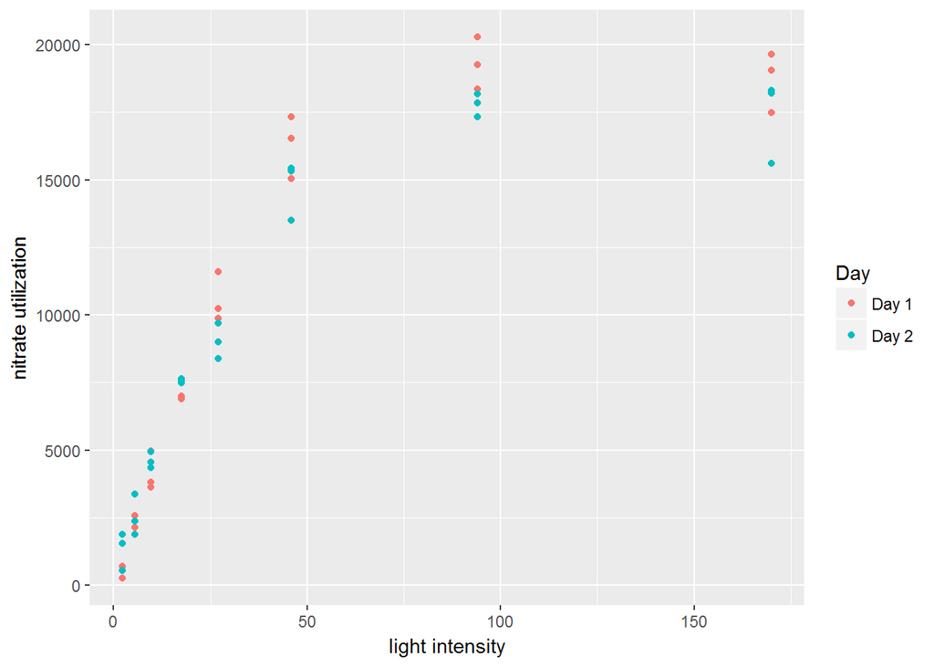

```r
ggplot(nitrate, aes(x = Light, y = Nitrate, colour = Day)) + geom_point() +
  xlab("light intensity") + ylab("nitrate utilization")
```

*Note that the experiment was carried out on two different days.*

**a)** Consider the Michaelis-Menten model $y_i=\frac{\beta_1x_i}{\beta_2+x_i}+\varepsilon_i$ with $\varepsilon_i\overset{iid}{\sim}N(0,\sigma^2)$. Choose suitable initial values for $\beta_1$ and $\beta_2$ and fit the model to the data (pool day 1 and day 2 observations) using the function `nls()`. Use `stat_function()` to add the fitted model to the scatterplot of the data. Discuss the adequacy of the fitted model. *(4 points)*

**b)** Investigate whether the parameters in the Michaelis-Menten model change with the day. Therefore, consider the following model

$$y_i=\frac{(\beta_1+\alpha_1z_i)x_i}{(\beta_2+\alpha_2z_i)+x_i}+\varepsilon_i,$$
where $\varepsilon_i\overset{iid}{\sim}N(0,\sigma^2)$ and $z$ is an indicator variable that is 1 if day 2 observations are involved and 0 otherwise. Choose suitable initial values for $\alpha_1$ and $\alpha_2$ and fit this model to the data by using the function `nls()` and the same initial values for $\beta_1$ and $\beta_2$, which have been used in part a). and add the fitted model for each of the two days by using again `stat_function()`. *(4 points)*

**c)** Decide if the modifications in part b) are needed. Therefore test the null hypothesis, that $\alpha_1=\alpha_2=0$. *(2 points)*

**General grading instructions:** For each part there exist also other approaches to solve the problem. Hence you have to check if solutions, which are different than the proposed one, are also correct.

*Remark:* If in the end the total number of points is not an integer (moodle only knows integers), you have to round up. So e.g. a result of 8.5 will be evaluated as 9 in moodle.

#### Solution

**a)** To fit the model with `nls()` we need suitable starting values for $\beta_1$ and $\beta_2$. For large values of $x$ the mean

$$\mu(x) = \frac{\beta_1 x}{\beta_2 + x}$$
will tend to $\beta_1$. So $\beta_1$ is an upper bound. Given the plot of the data we choose 21000 as starting value for $\beta_1$. Given this starting value we now take any of the light values and the average of the corresponding nitrate values to compute a starting value for $\beta_2$.

```r
unique(nitrate$Light)
```

```
## [1]   2.2   5.5   9.6  17.5  27.0  46.0  94.0 170.0
```

The most information about $\beta_2$ is probably contained in the observations with small light intensity. Hence we will consider `Light` equal to 2.2. Solving the mean model for $\beta_2$ yields

$$\beta_2 = \frac{\beta_1 x - \mu(x)x}{\mu(x)}\,,$$

which yields

```r
(21000 * 2.2 - mean(nitrate$Nitrate[nitrate$Light == 2.2] * 2.2)) / mean(nitrate$Nitrate[nitrate$Light == 2.2])
```

```
## [1] 40.71686
```

So we choose a starting value of 40.

```r
(mime <- nls(Nitrate ~ beta1 * Light / (beta2 + Light), start = list(beta1=21000, beta2=40),
            data = nitrate))
```

```
## Nonlinear regression model
##   model: Nitrate ~ beta1 * Light/(beta2 + Light)
##    data: nitrate
##    beta1    beta2
## 23582.47    34.24
##  residual sum-of-squares: 96536196
##
## Number of iterations to convergence: 7
## Achieved convergence tolerance: 2.01e-06
```

Now we add the fitted regression line to the scatterplot of the data. Therefore we define a function, which consists of the Michaelis-Menton model for the estimated coefficients $\beta_1$ and $\beta_2$. The estimated values can be provided using the argument `args` of the function `stat_function()`.

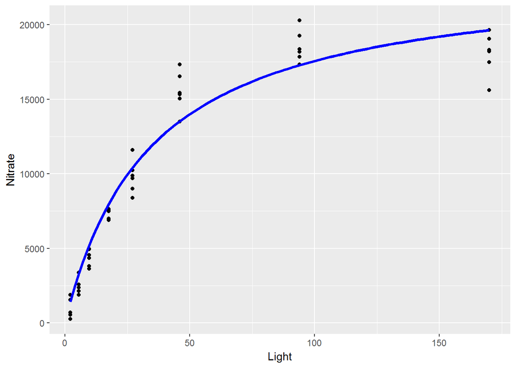

```r
mm <- function(x, beta_1, beta_2){beta_1 * x / (beta_2 + x)}

ggplot(nitrate) + geom_point(aes(x = Light, y = Nitrate))  +
  stat_function(fun = mm, args = list(beta_1 = coef(mime)[1], beta_2 = coef(mime)[2]), colour = "blue", size = 1.3)
```

The overlay of the fitted model to the data shows that the Michaelis-Menten model fits the given data quite well. But since we have grouped data, we can actually test if there is a lack of fit. If we take a look at the lack-of-fit test from Chapter 5, we see that it only depends on

- grouped data
- a model describing the conditional mean
- the normal distribution of the error term

To perform the test, we need (for comparison) the unrestricted model

```r
model_unres <- lm(Nitrate ~ factor(Light), data = nitrate)
```

and compare the two models with `anova()`

```r
anova(mime, model_unres)
```

```
## Analysis of Variance Table
##
## Model 1: Nitrate ~ beta1 * Light/(beta2 + Light)
## Model 2: Nitrate ~ factor(Light)
##   Res.Df Res.Sum Sq Df   Sum Sq F value  Pr(>F)
## 1     46   96536196
## 2     40   36514340  6 60021856  10.959 3.4e-07 ***
## ---
## Signif. codes:  0 '***' 0.001 '**' 0.01 '*' 0.05 '.' 0.1 ' ' 1
```

We detect a rather larger F value, which indicates that there is a lack of fit.

*Grading:* If `nls()` is used in a correct way (which means applied to the correct model), one gets **1 point** (the computed estimates do not have to be correct). For starting values, which lead to the correct estimates for $\beta_1$ and $\beta_2$ one gets **1 point**. If `stat_function()` is used in a correct way to plot the Michaelis-Menten (the parameter values do not have to be correct), one gets **1 point**. For arguing that there is a lack of fit, one gets **1 point**.

**b)**

In this part we want to take into account the influence of `Day`. Since `Day` is a character vector

```r
nitrate
```

```
## # A tibble: 48 × 3
##    Light Nitrate   Day
##    <dbl>   <int> <chr>
## 1    2.2     256 Day 1
## 2    2.2     685 Day 1
## 3    2.2    1537 Day 1
## 4    5.5    2148 Day 1
## 5    5.5    2583 Day 1
## 6    5.5    3376 Day 1
## 7    9.6    3634 Day 1
## 8    9.6    4960 Day 1
## 9    9.6    3814 Day 1
## 10  17.5    6986 Day 1
## # ... with 38 more rows
```

we have to convert the information in `Day` to appropriate numeric values. This means we need a vector with zeros and ones, where the ones indicate Day 2.

```r
nitrate$Day_num <- c(rep(0, 24), rep(1, 24))
```

To fit the model, we also need starting values for $\alpha_1$ and $\alpha_2$. The first parameter shifts the upper bound with respect to day. For Day 2 we detect a maximal value, which is roughly 3000 units smaller than for Day 1. Concerning $\alpha_2$ we may compute

```r
(18000 * 2.2 - mean(nitrate$Nitrate[nitrate$Light == 2.2 & nitrate$Day == "Day 2"] * 2.2)) / mean(nitrate$Nitrate[nitrate$Light == 2.2 & nitrate$Day == "Day 2"])
```

```
## [1] 27.64175
```

which leads to a starting value of -13.

```r
mime_day <- nls(Nitrate ~ (beta1 + alpha1 * Day_num) * Light / ((beta2 + alpha2 * Day_num) + Light),
             start = list(beta1=21000, beta2=40, alpha1=-3000, alpha2=-13), data = nitrate)
summary(mime_day)
```

```
##
## Formula: Nitrate ~ (beta1 + alpha1 * Day_num) * Light/((beta2 + alpha2 *
##     Day_num) + Light)
##
## Parameters:
##         Estimate Std. Error t value Pr(>|t|)
## beta1  24743.211   1241.165  19.935  < 2e-16 ***
## beta2     35.275      4.657   7.575 1.66e-09 ***
## alpha1 -2328.619   1720.378  -1.354    0.183
## alpha2    -2.172      6.626  -0.328    0.745
## ---
## Signif. codes:  0 '***' 0.001 '**' 0.01 '*' 0.05 '.' 0.1 ' ' 1
##
## Residual standard error: 1402 on 44 degrees of freedom
##
## Number of iterations to convergence: 7
## Achieved convergence tolerance: 4.844e-06
```

Now we plot again the data together with the fitted model. Therefore we will define a new function for the given fitted model.

```r
mm_day <- function(x, beta_1, beta_2, alpha_1, alpha_2){
  (beta_1 + alpha_1) * x / ((beta_2 + alpha_2) + x)
}
```

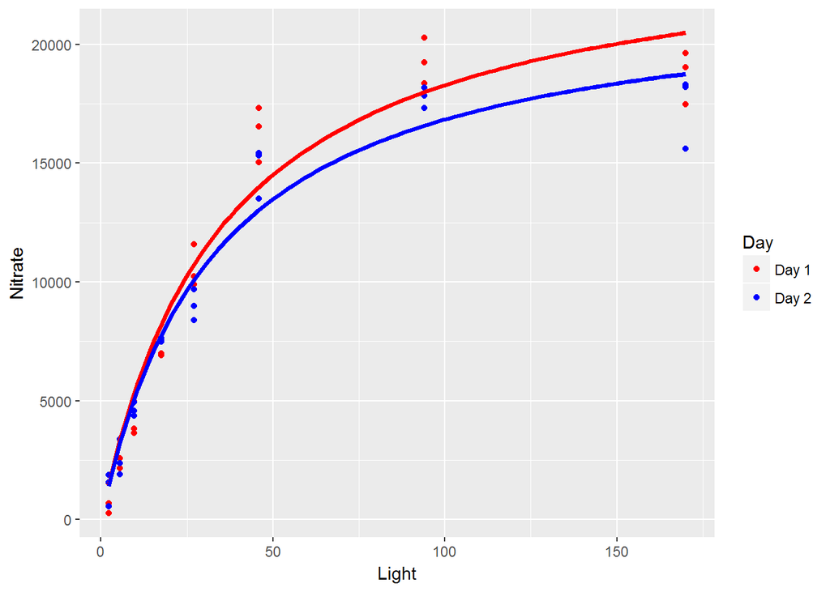

```r
ggplot(nitrate, aes(x = Light, y = Nitrate, colour = Day)) + geom_point() +
  scale_color_manual(breaks = c("Day 1", "Day 2"),values=c("red", "blue"), name = "Day") +
    stat_function(fun = mm_day, args = list(beta_1 = coef(mime_day)[1], beta_2 = coef(mime_day)[2],
                                            alpha_1 = 0, alpha_2 = 0),
                  colour = "red", size = 1.3) +
    stat_function(fun = mm_day, args = list(beta_1 = coef(mime_day)[1], beta_2 = coef(mime_day)[2],
                                            alpha_1 = coef(mime_day)[3], alpha_2 = coef(mime_day)[4]),
                  colour = "blue", size = 1.3)
```

*Grading:* For coding the information about the two different days in such a way that it can be used in `nls()` (`Day_num` in the solution), one gets **1 point**. If `nls()` is used in a correct way (which means applied to the correct model), one gets **1 point** (the computed estimates do not have to be correct). For starting values (for $\alpha_1$ and $\alpha_2$), which lead to the correct estimates for $\beta_1, \beta_2, \alpha_1$ and $\alpha_2$ one gets **1 point**. If `stat_function()` is used in a correct way to plot the extended Michaelis-Menten, which means that two curves have to be plotted (the parameter values do not have to be correct), one gets **1 point**.

**c)**

To determine whether the additional parameters are needed, we test the null hypothesis

$$H_0:\, \alpha_1 = \alpha_2 = 0\,.$$

```r
anova(mime, mime_day)
```

```
## Analysis of Variance Table
##
## Model 1: Nitrate ~ beta1 * Light/(beta2 + Light)
## Model 2: Nitrate ~ (beta1 + alpha1 * Day_num) * Light/((beta2 + alpha2 * Day_num) + Light)
##   Res.Df Res.Sum Sq Df   Sum Sq F value  Pr(>F)
## 1     46   96536196
## 2     44   86509529  2 10026666  2.5499 0.08958 .
## ---
## Signif. codes:  0 '***' 0.001 '**' 0.01 '*' 0.05 '.' 0.1 ' ' 1
```

Since the p-value is greater than 0.05, we can’t reject the null hypothesis. But it is just slightly larger. Hence, it might be doubtful, if a model without the influence of day is a good model for the data.

*Grading:* One gets **1 point** for using `anova()` with both models as input. For giving the correct interpretation of the ANOVA output one gets **1 point**. Remember that the level was not specified. So, e.g. for a chosen level of 0.1 one can argue that the null hypothesis is rejected.